# Презентация по лабораторной работе №1

Подготовка лабораторного стенда

Лушин А.А.

Российский университет дружбы народов, Москва, Россия

Факультет Физико-математических и естественных наук

# Информация

## Докладчик

- Лушин Артём Андреевич
- Бакалавр направления компьютерные и информационные науки
- Кафедра теории вероятности и кибербезопасности
- Российский университет дружбы народов
- Редактор Первого Федерального канала
- lusin5745@gmail.com

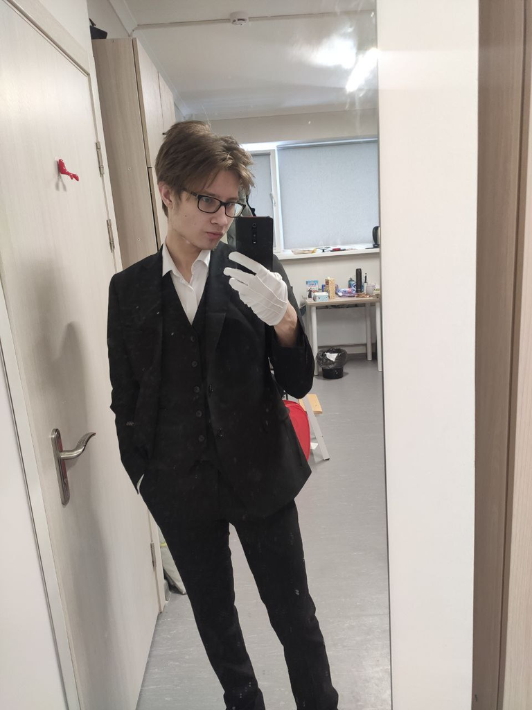

# Вводная часть

## Цели и задачи

Целью данной работы является приобретение практических навыков установки Rocky Linux на виртуальную машину с помощью инструманте Vagrant.

# Ход работы

## Создание рабочей зоны

Я выполняю лабораторную работу на ОС Windows, поэтому все папки и каталоги будут находиться на этой ОС. Сначала я создал папку packer и vagrant. Затем в каждом из папок создал подкаталоги. В packer я разместил файл vagrant-rocky.pkr.hcl. В подкаталоге vagrant разместил ещё один подкаталог http с файлом ks.cfg. Так же в каталоге vagrant мы разместили vagrantfile и Makefile.

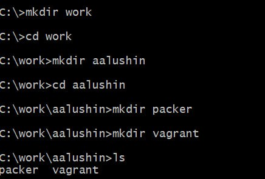

## Создание основных скриптов

В каталоге vagrant мы создали ещё три подкаталога default, server, client. В каждом из этих подкаталогов я разместил скрипт-заглушки: 01-dummy.sh. В каталоге default я разместил скрипт 01-user.sh. Также в default мы разместили 01-hostname.sh. В каталоге server у нас находятся 02-forward.sh. И в client размещён 02-routing.sh.

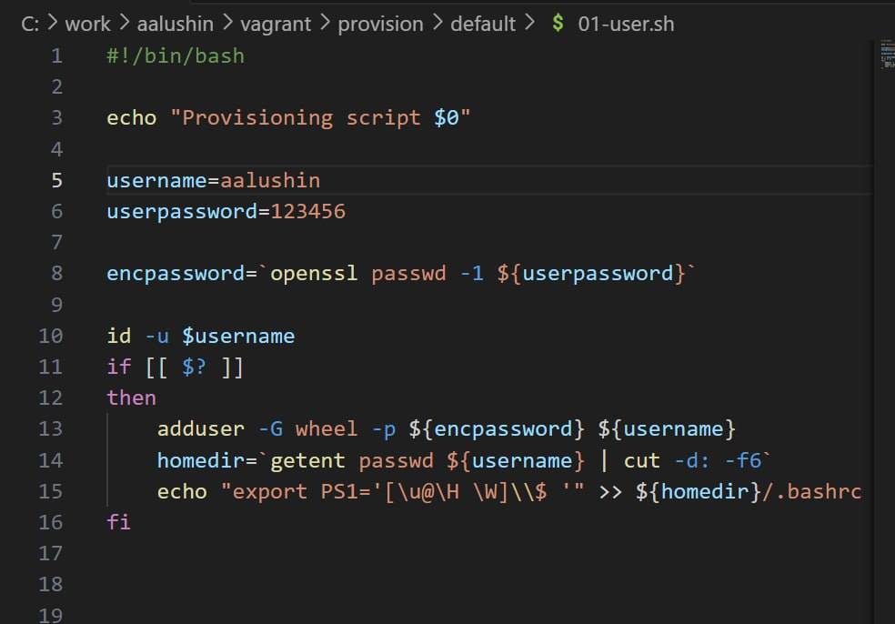

## Запуск виртуальной машины

Мы зарегистрировали образ виртуальной ОС с помощью команды. Запустили первую ОС - server и вторую - client.

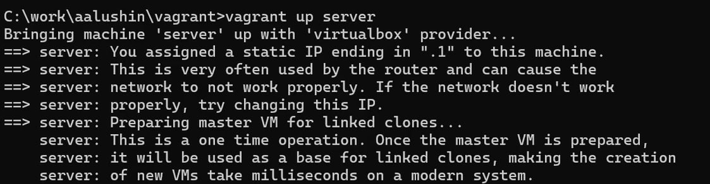

## Проверка работоспособности

После запуска двух машин одновременно убедились, что они обе работают и никак не вылетают. Подключились к серверу и клиенту из консоли.

[figure not shown]

## Итоговая проверка

Зафиксировали внесённые изменения для внутренних настроек виртуальной машины. Сменили пользователей в vagrant на локальных, то есть на aalushin. Выключили машины и сохранили на переносные устройства.

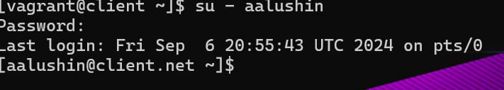

# Результаты

## Вывод

Я приобрёл практические навыки установки Rocky Linux на виртуальную машину с помощью инструмента vagrant.

## Контрольные вопросы

1. Для чего предназначен Vagrant?

Ответ: Инструмент для создания и управления средами виртуальных машин в одном рабочем процессе.

Пример содержимого файла Vagrantfile: # -*- mode: ruby -*- # vi: set ft=ruby : Vagrant.configure(2) do |config|

config.vm.box = “BOX_NAME” config.vm.hostname = “HOST_NAME” config.vm.network “private_network”, ip: “192.168.1.1” config.vm.define “VM_NAME” config.vm.provider “virtualbox” do |vb| vb.gui = false vb.memory = “1024” end end

Первые две строки указывают на режим работы с Vagrantfile и использование языка Ruby. Затем идёт цикл do, заменяющий конструкцию Vagrant.configure далее по текстуна config. Строка config.vm.box = “BOX_NAME” задаёт название образа (box-файла) виртуальной машины (обычно выбирается из официального репозитория). Строка config.vm.hostname = “HOST_NAME” задаёт имя виртуальной машины. Конструкция config.vm.network задаёт тип сетевого соединения и может иметь следующие назначения:

- config.vm.network “private_network”, ip: “xxx.xxx.xxx.xxx” — адрес из внутренней сети;
- config.vm.network “public_network”, ip: “xxx.xxx.xxx.xxx” — публичный адрес, по которому виртуальная машина будет доступна;
- config.vm.network “private_network”, type: “dhcp” — адрес, назначаемый по протоколу DHCP.

Строка config.vm.define “VM_NAME” задаёт название виртуальной машины, по которому можно обращаться к ней из Vagrant и VirtualBox. В конце идёт конструкция, определяющая параметры провайдера, а именно запуск виртуальной машины без графического интерфейса и с выделением 1 ГБ памяти.